# Malaria

Zachary Hamilton

20/11/2018

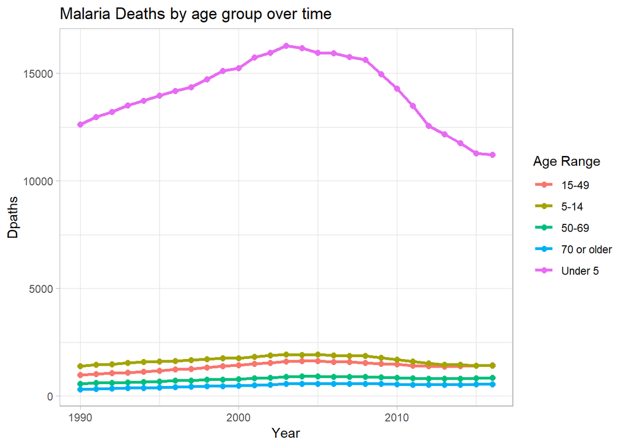

The Under 5 Age group stands out as the demographic that is most often fatally affected by malaria.

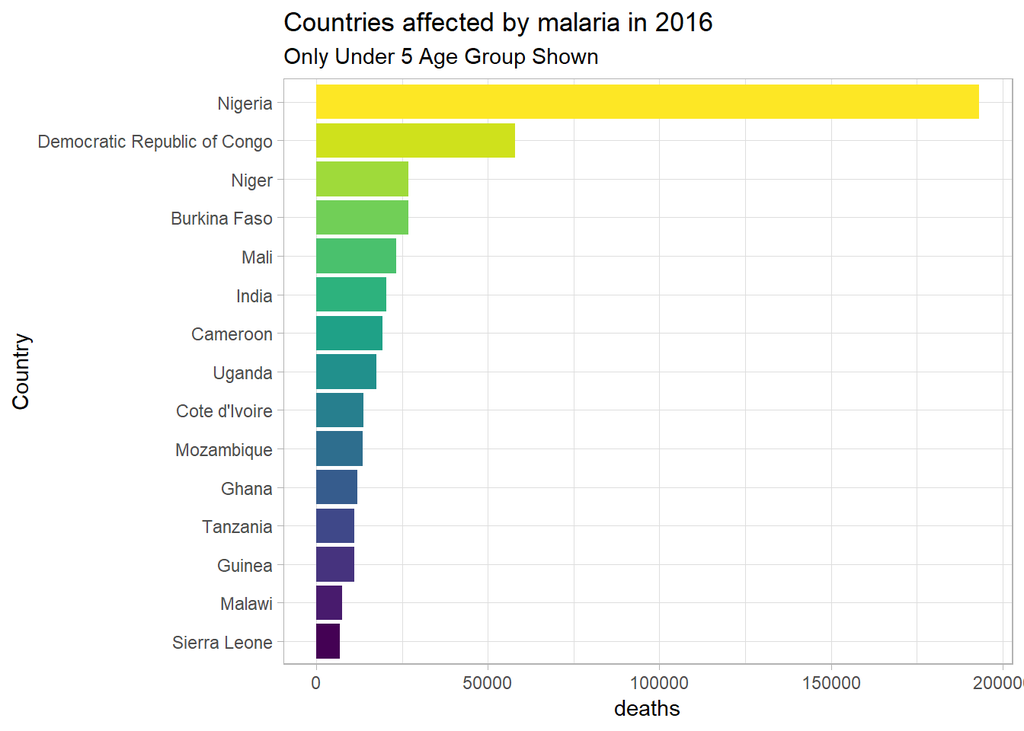

Nigeria had roughly triple the amount of deaths as the next highest country, the overwhelming majority are African countries, with the major exception of India, which makes me think I should probably make some sort of per capita adjustment instead of looking at overall counts. Let’s find a world population table to join on and make some calculations - good old gapminder might do the trick.

```
## # A tibble: 1 x 1
##   `max(year)`
##         <dbl>
## 1        2007
```

Most recent data available in gapminder dataset is 2007, this most certainly WILL NOT do!

```
## Observations: 30,780
## Variables: 5
## $ entity    <chr> "Afghanistan", "Afghanistan", "Afghanistan", "Afghan...
## $ code      <chr> "AFG", "AFG", "AFG", "AFG", "AFG", "AFG", "AFG", "AF...
## $ year      <dbl> 1990, 1991, 1992, 1993, 1994, 1995, 1996, 1997, 1998...
## $ age_group <chr> "Under 5", "Under 5", "Under 5", "Under 5", "Under 5...
## $ deaths    <dbl> 184.6064, 191.6582, 197.1402, 207.3578, 226.2094, 23...
```

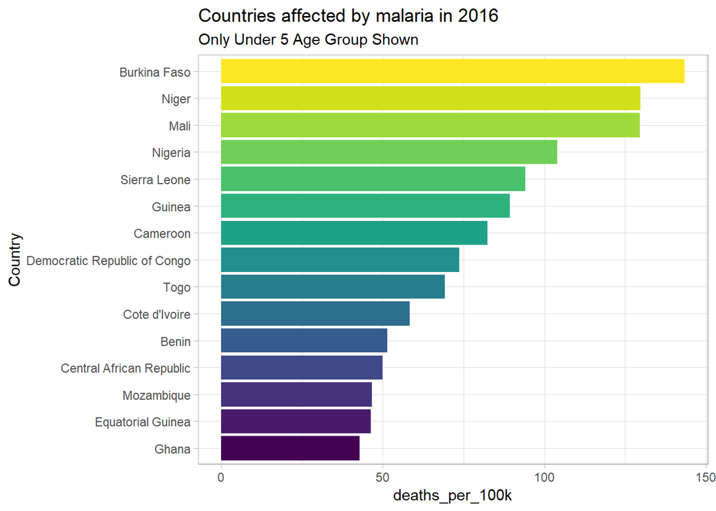

```
## Observations: 975
## Variables: 7
## $ entity          <chr> "Afghanistan", "Albania", "Algeria", "American...
## $ code            <chr> "AFG", "ALB", "DZA", "ASM", "AND", "AGO", "ATG...
## $ year            <dbl> 2016, 2016, 2016, 2016, 2016, 2016, 2016, 2016...
## $ age_group       <chr> "Under 5", "Under 5", "Under 5", "Under 5", "U...
## $ deaths          <dbl> 4.097856e+02, 0.000000e+00, 2.848426e-01, 4.70...
## $ value           <dbl> 34656032, 2876101, 40606052, 55599, 77281, 288...
## $ deaths_per_100k <dbl> 1.182437e+00, 0.000000e+00, 7.014783e-04, 8.46...
```

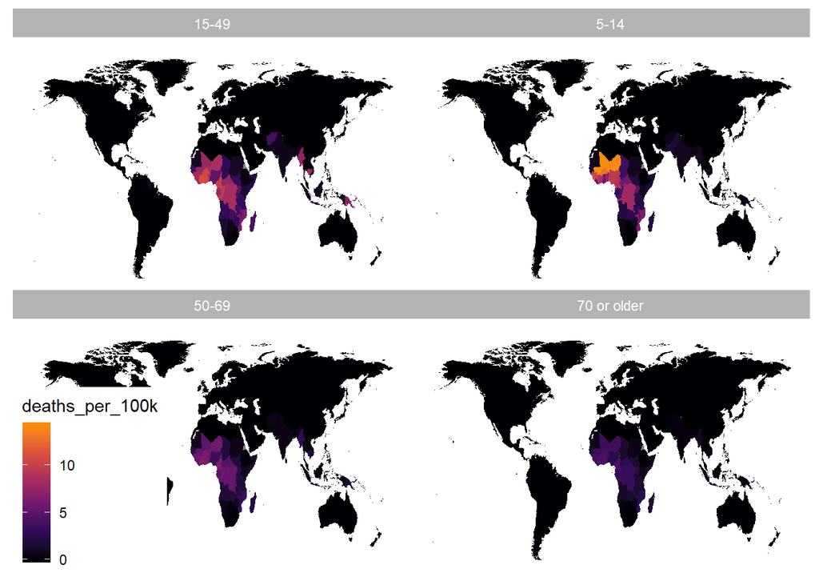